# Personal Loan Campaign - Problem Statement

### Model Performance Comparison

```python
# training performance comparison

models_train_comp_df = pd.concat(
    [
        log_reg_model_train_perf.T,
        log_reg_model_train_perf_threshold_auc_roc.T,
        log_reg_model_train_perf_threshold_curve.T,
    ],
    axis=1,
)
models_train_comp_df.columns = [
    "Logistic Regression sklearn",
    "Logistic Regression-0.11 Threshold",
    "Logistic Regression-0.32 Threshold",
]

print("Training performance comparison:")
models_train_comp_df
```

```
Training performance comparison:
```

|  | Logistic Regression sklearn | Logistic Regression-0.11 Threshold | Logistic Regression-0.32 Threshold |
| --- | --- | --- | --- |
| Accuracy | 0.938571 | 0.856286 | 0.938857 |
| Recall | 0.478916 | 0.915663 | 0.641566 |
| Precision | 0.791045 | 0.390244 | 0.691558 |
| F1 | 0.596623 | 0.547255 | 0.665625 |

```python
# testing performance comparison

models_test_comp_df = pd.concat(
    [
        log_reg_model_test_perf.T,
        log_reg_model_test_perf_threshold_auc_roc.T,
        log_reg_model_test_perf_threshold_curve.T,
    ],
    axis=1,
)
models_test_comp_df.columns = [
    "Logistic Regression sklearn",
    "Logistic Regression-0.11 Threshold",
    "Logistic Regression-0.32 Threshold",
]

print("Test set performance comparison:")
models_test_comp_df
```

```
Test set performance comparison:
```

|  | Logistic Regression sklearn | Logistic Regression-0.11 Threshold | Logistic Regression-0.32 Threshold |
| --- | --- | --- | --- |
| Accuracy | 0.942667 | 0.852000 | 0.939333 |
| Recall | 0.506757 | 0.932432 | 0.648649 |
| Precision | 0.852273 | 0.394286 | 0.711111 |
| F1 | 0.635593 | 0.554217 | 0.678445 |

### MODEL BUILDING - DECISION TREE

```python
model0 = DecisionTreeClassifier(random_state=1)
model0.fit(X_train, y_train)
```

```
DecisionTreeClassifier(random_state=1)
```

#### Defining our Model Evaluation

```python
# defining a function to compute different metrics to check performance of a classification model built using sklearn
def model_performance_classification_sklearn(model, predictors, target):
    """
    Function to compute different metrics to check classification model performance

    model: classifier
    predictors: independent variables
    target: dependent variable
    """

    # predicting using the independent variables
    pred = model.predict(predictors)

    acc = accuracy_score(target, pred)  # to compute Accuracy
    recall = recall_score(target, pred)  # to compute Recall
    precision = precision_score(target, pred)  # to compute Precision
    f1 = f1_score(target, pred)  # to compute F1-score

    # creating a dataframe of metrics
    df_perf2 = pd.DataFrame(
        {"Accuracy": acc, "Recall": recall, "Precision": precision, "F1": f1,},
        index=[0],
    )

    return df_perf2
```

```python
def confusion_matrix_sklearn(model, predictors, target):
    """
    To plot the confusion_matrix with percentages

    model: classifier
    predictors: independent variables
    target: dependent variable
    """
    y_pred = model.predict(predictors)
    cm = confusion_matrix(target, y_pred)
    labels = np.asarray(
        [
            ["{0:0.0f}".format(item) + "\n{0:.2%}".format(item / cm.flatten().sum())]
            for item in cm.flatten()
        ]
    ).reshape(2, 2)

    plt.figure(figsize=(6, 4))
    sns.heatmap(cm, annot=labels, fmt="")
    plt.ylabel("True label")
    plt.xlabel("Predicted label")
```

- **Checking Model Performance on Training set**

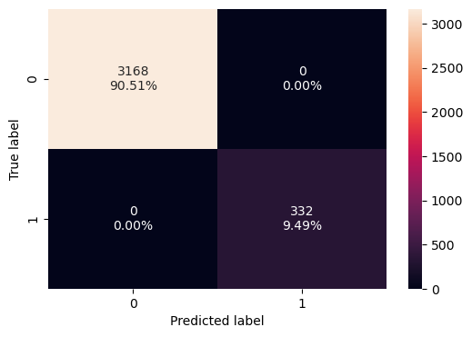

```python
confusion_matrix_sklearn(model0, X_train, y_train)
```

```python
decision_tree_perf_train_without = model_performance_classification_sklearn(
    model0, X_train, y_train
)
decision_tree_perf_train_without
```

|  | Accuracy | Recall | Precision | F1 |
| --- | --- | --- | --- | --- |
| 0 | 1.0 | 1.0 | 1.0 | 1.0 |

- **Checking Model performance on Test set**

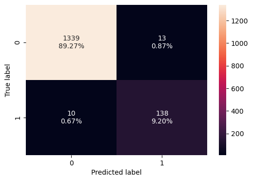

```python
confusion_matrix_sklearn(model0, X_test, y_test)
```

```python
decision_tree_perf_test_without = model_performance_classification_sklearn(
    model0, X_test, y_test
)
decision_tree_perf_test_without
```

|  | Accuracy | Recall | Precision | F1 |
| --- | --- | --- | --- | --- |
| 0 | 0.984667 | 0.932432 | 0.913907 | 0.923077 |

- The Recall for the test and precision is very high so this Model is working very well
- **Decision Tree (with class_weights)**
- Adding Class_weights to our Model

```python
model1 = DecisionTreeClassifier(random_state=1, class_weight="balanced")
model1.fit(X_train, y_train)
```

```
DecisionTreeClassifier(class_weight='balanced', random_state=1)
```

- **Checking Model Performance on Training set**

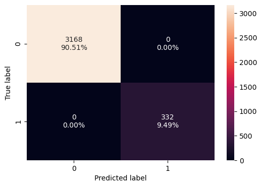

```python
confusion_matrix_sklearn(model1, X_train, y_train)
```

```python
decision_tree_perf_train = model_performance_classification_sklearn(
    model1, X_train, y_train
)
decision_tree_perf_train
```

|  | Accuracy | Recall | Precision | F1 |
| --- | --- | --- | --- | --- |
| 0 | 1.0 | 1.0 | 1.0 | 1.0 |

- **Checking Model on Test Data**

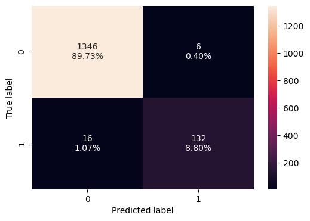

```python
confusion_matrix_sklearn(model1, X_test, y_test)
```

```python
decision_tree_perf_test = model_performance_classification_sklearn(
    model1, X_test, y_test
)
decision_tree_perf_test
```

|  | Accuracy | Recall | Precision | F1 |
| --- | --- | --- | --- | --- |
| 0 | 0.985333 | 0.891892 | 0.956522 | 0.923077 |

### Decision Tree (Pre-pruning)

- **Using GridSearch for Hyperparameter tuning of our tree model**

```python
# Choose the type of classifier.
estimator = DecisionTreeClassifier(random_state=1)

# Grid of parameters to choose from
parameters = {
    "class_weight": [None, "balanced"],
    "max_depth": np.arange(2, 7, 2),
    "max_leaf_nodes": [50, 75, 150, 250],
    "min_samples_split": [10, 30, 50, 70],
}

# Type of scoring used to compare parameter combinations
acc_scorer = make_scorer(recall_score)

# Run the grid search
grid_obj = GridSearchCV(estimator, parameters, scoring=acc_scorer, cv=5)
grid_obj = grid_obj.fit(X_train, y_train)

# Set the clf to the best combination of parameters
estimator = grid_obj.best_estimator_

# Fit the best algorithm to the data.
estimator.fit(X_train, y_train)
```

```
DecisionTreeClassifier(class_weight='balanced', max_depth=6, max_leaf_nodes=50,
                       min_samples_split=70, random_state=1)
```

- **Checking Model Performance on Training set**

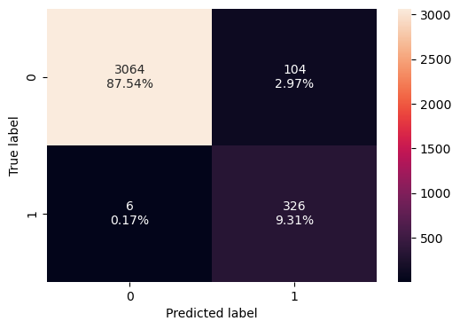

```python
confusion_matrix_sklearn(estimator, X_train, y_train)
```

```python
decision_tree_tune_perf_train = model_performance_classification_sklearn(
    estimator, X_train, y_train
)
decision_tree_tune_perf_train
```

|  | Accuracy | Recall | Precision | F1 |
| --- | --- | --- | --- | --- |
| 0 | 0.968571 | 0.981928 | 0.75814 | 0.855643 |

- **Checking Model Performance on test data**

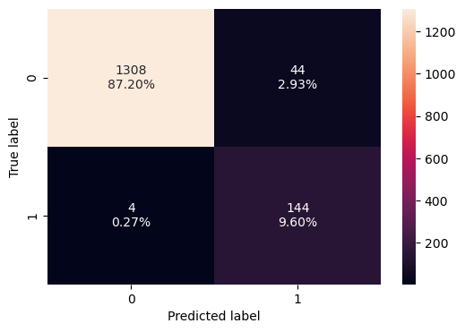

```python
confusion_matrix_sklearn(estimator, X_test, y_test)
```

```python
decision_tree_tune_perf_test = model_performance_classification_sklearn(
    estimator, X_test, y_test
)
decision_tree_tune_perf_test
```

|  | Accuracy | Recall | Precision | F1 |
| --- | --- | --- | --- | --- |
| 0 | 0.968 | 0.972973 | 0.765957 | 0.857143 |

- This Model is also working very well. There is generalization and balance in every aspect of the Evaluations

### Visualising our Decision Tree to see the depth.

```python
feature_names = list(X_train.columns)
importances = estimator.feature_importances_
indices = np.argsort(importances)
```

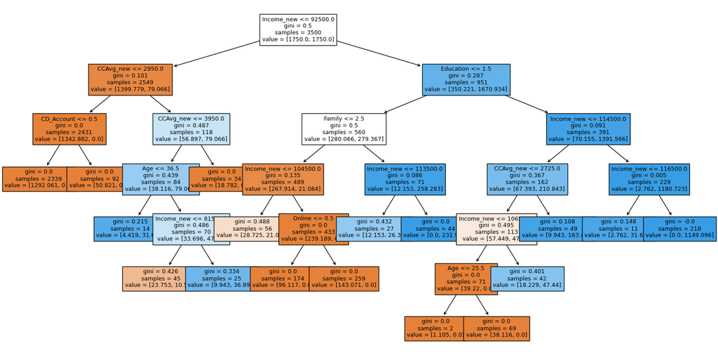

```python
plt.figure(figsize=(20, 10))
out = tree.plot_tree(
    estimator,
    feature_names=feature_names,
    filled=True,
    fontsize=9,
    node_ids=False,
    class_names=None,
)
# below code will add arrows to the decision tree split if they are missing
for o in out:
    arrow = o.arrow_patch
    if arrow is not None:
        arrow.set_edgecolor("black")
        arrow.set_linewidth(1)
plt.show()
```

```python
# Text report showing the rules of a decision tree -
print(tree.export_text(estimator, feature_names=feature_names, show_weights=True))
```

```
|--- Income_new <= 92500.00
|   |--- CCAvg_new <= 2950.00
|   |   |--- CD_Account <= 0.50
|   |   |   |--- weights: [1292.06, 0.00] class: 0
|   |   |--- CD_Account >  0.50
|   |   |   |--- weights: [50.82, 0.00] class: 0
|   |--- CCAvg_new >  2950.00
|   |   |--- CCAvg_new <= 3950.00
|   |   |   |--- Age <= 36.50
|   |   |   |   |--- weights: [4.42, 31.63] class: 1
|   |   |   |--- Age >  36.50
|   |   |   |   |--- Income_new <= 81500.00
|   |   |   |   |   |--- weights: [23.75, 10.54] class: 0
|   |   |   |   |--- Income_new >  81500.00
|   |   |   |   |   |--- weights: [9.94, 36.90] class: 1
|   |   |--- CCAvg_new >  3950.00
|   |   |   |--- weights: [18.78, 0.00] class: 0
|--- Income_new >  92500.00
|   |--- Education <= 1.50
|   |   |--- Family <= 2.50
|   |   |   |--- Income_new <= 104500.00
|   |   |   |   |--- weights: [28.72, 21.08] class: 0
|   |   |   |--- Income_new >  104500.00
|   |   |   |   |--- Online <= 0.50
|   |   |   |   |   |--- weights: [96.12, 0.00] class: 0
|   |   |   |   |--- Online >  0.50
|   |   |   |   |   |--- weights: [143.07, 0.00] class: 0
|   |   |--- Family >  2.50
|   |   |   |--- Income_new <= 113500.00
|   |   |   |   |--- weights: [12.15, 26.36] class: 1
|   |   |   |--- Income_new >  113500.00
|   |   |   |   |--- weights: [0.00, 231.93] class: 1
|   |--- Education >  1.50
|   |   |--- Income_new <= 114500.00
|   |   |   |--- CCAvg_new <= 2725.00
|   |   |   |   |--- Income_new <= 106500.00
|   |   |   |   |   |--- Age <= 25.50
|   |   |   |   |   |   |--- weights: [1.10, 0.00] class: 0
|   |   |   |   |   |--- Age >  25.50
|   |   |   |   |   |   |--- weights: [38.12, 0.00] class: 0
|   |   |   |   |--- Income_new >  106500.00
|   |   |   |   |   |--- weights: [18.23, 47.44] class: 1
|   |   |   |--- CCAvg_new >  2725.00
|   |   |   |   |--- weights: [9.94, 163.40] class: 1
|   |   |--- Income_new >  114500.00
|   |   |   |--- Income_new <= 116500.00
|   |   |   |   |--- weights: [2.76, 31.63] class: 1
|   |   |   |--- Income_new >  116500.00
|   |   |   |   |--- weights: [0.00, 1149.10] class: 1
```

```python
importances = estimator.feature_importances_
importances
```

```
array([2.63850057e-03, 1.34133094e-01, 1.02278608e-01, 0.00000000e+00,
       1.43491844e-14, 1.01577436e-15, 0.00000000e+00, 6.80950125e-01,
       0.00000000e+00, 7.99996719e-02])
```

### Important Features in our decision Tree

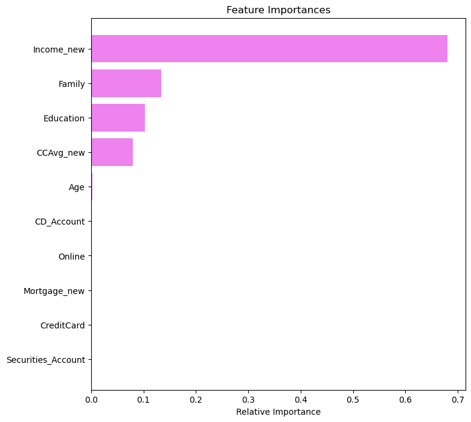

```python
# importance of features in the tree building

importances = estimator.feature_importances_
indices = np.argsort(importances)

plt.figure(figsize=(8, 8))
plt.title("Feature Importances")
plt.barh(range(len(indices)), importances[indices], color="violet", align="center")
plt.yticks(range(len(indices)), [feature_names[i] for i in indices])
plt.xlabel("Relative Importance")
plt.show()
```

- In the pre tuned decision tree also, Income,Family,Education and CCAvg_new are the most important features.

### Decision Tree (Post Pruning)

```python
clf = DecisionTreeClassifier(random_state=1, class_weight="balanced")
path = clf.cost_complexity_pruning_path(X_train, y_train)
ccp_alphas, impurities = abs(path.ccp_alphas), path.impurities
```

```python
pd.DataFrame(path)
```

|  | ccp_alphas | impurities |
| --- | --- | --- |
| 0 | 0.000000e+00 | -9.978935e-18 |
| 1 | 1.051348e-19 | -9.873800e-18 |
| 2 | 2.277920e-18 | -7.595881e-18 |
| 3 | 3.732284e-18 | -3.863597e-18 |
| 4 | 6.621210e-17 | 6.234850e-17 |
| 5 | 1.093503e-16 | 1.716988e-16 |
| 6 | 4.704079e-16 | 6.421067e-16 |
| 7 | 6.645147e-15 | 7.287254e-15 |
| 8 | 1.525010e-04 | 3.050020e-04 |
| 9 | 1.537988e-04 | 6.125997e-04 |
| 10 | 1.569147e-04 | 9.264291e-04 |
| 11 | 2.850845e-04 | 1.211514e-03 |
| 12 | 2.857143e-04 | 1.782942e-03 |
| 13 | 2.950433e-04 | 2.963115e-03 |
| 14 | 2.999400e-04 | 3.263055e-03 |
| 15 | 2.999400e-04 | 4.162875e-03 |
| 16 | 3.050020e-04 | 4.467877e-03 |
| 17 | 3.075977e-04 | 4.775475e-03 |
| 18 | 3.102378e-04 | 5.085713e-03 |
| 19 | 3.373897e-04 | 5.760492e-03 |
| 20 | 4.456733e-04 | 6.651839e-03 |
| 21 | 5.177421e-04 | 7.169581e-03 |
| 22 | 5.465486e-04 | 7.716130e-03 |
| 23 | 5.703655e-04 | 8.286495e-03 |
| 24 | 5.703655e-04 | 8.856860e-03 |
| 25 | 5.895822e-04 | 9.446443e-03 |
| 26 | 5.921347e-04 | 1.418352e-02 |
| 27 | 6.557422e-04 | 1.680649e-02 |
| 28 | 6.791967e-04 | 1.748569e-02 |
| 29 | 7.657414e-04 | 1.825143e-02 |
| 30 | 8.896797e-04 | 1.914111e-02 |
| 31 | 9.314227e-04 | 2.007253e-02 |
| 32 | 1.040704e-03 | 2.111323e-02 |
| 33 | 1.115386e-03 | 2.222862e-02 |
| 34 | 1.201167e-03 | 2.342979e-02 |
| 35 | 1.315837e-03 | 2.474562e-02 |
| 36 | 1.412946e-03 | 2.615857e-02 |
| 37 | 1.460851e-03 | 2.908027e-02 |
| 38 | 1.817455e-03 | 3.089773e-02 |
| 39 | 1.869823e-03 | 3.276755e-02 |
| 40 | 1.879525e-03 | 3.464707e-02 |
| 41 | 1.916086e-03 | 3.847925e-02 |
| 42 | 4.211086e-03 | 4.269033e-02 |
| 43 | 4.236889e-03 | 5.116411e-02 |
| 44 | 7.322632e-03 | 5.848674e-02 |
| 45 | 8.193068e-03 | 7.487288e-02 |
| 46 | 2.385820e-02 | 9.873107e-02 |
| 47 | 5.474146e-02 | 2.082140e-01 |
| 48 | 2.917860e-01 | 5.000000e-01 |

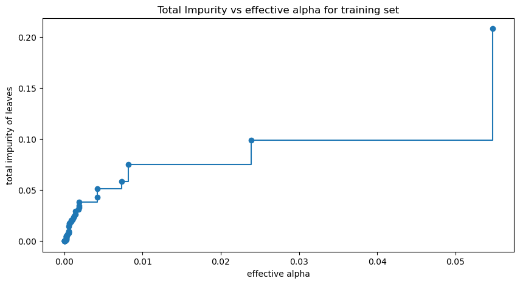

```python
fig, ax = plt.subplots(figsize=(10, 5))
ax.plot(ccp_alphas[:-1], impurities[:-1], marker="o", drawstyle="steps-post")
ax.set_xlabel("effective alpha")
ax.set_ylabel("total impurity of leaves")
ax.set_title("Total Impurity vs effective alpha for training set")
plt.show()
```

- Next, we train a decision tree using the effective alphas. The last value in ccp_alphas is the alpha value that prunes the whole tree, leaving the tree, clfs[-1], with one node.

```python
clfs = []
for ccp_alpha in ccp_alphas:
    clf = DecisionTreeClassifier(
        random_state=1, ccp_alpha=ccp_alpha, class_weight="balanced"
    )
    clf.fit(X_train, y_train)
    clfs.append(clf)
print(
    "Number of nodes in the last tree is: {} with ccp_alpha: {}".format(
        clfs[-1].tree_.node_count, ccp_alphas[-1]
    )
)
```

```
Number of nodes in the last tree is: 1 with ccp_alpha: 0.2917860065975936
```

- For the remainder, we remove the last element in clfs and ccp_alphas, because it is the trivial tree with only one node. Here we show that the number of nodes and tree depth decreases as alpha increases.

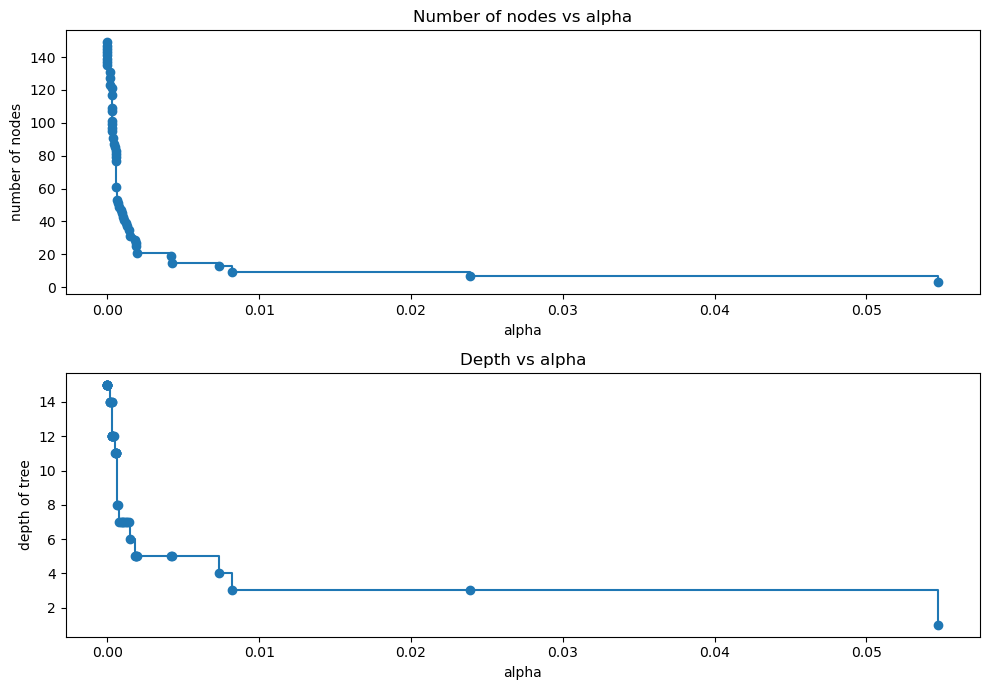

```python
clfs = clfs[:-1]
ccp_alphas = ccp_alphas[:-1]

node_counts = [clf.tree_.node_count for clf in clfs]
depth = [clf.tree_.max_depth for clf in clfs]
fig, ax = plt.subplots(2, 1, figsize=(10, 7))
ax[0].plot(ccp_alphas, node_counts, marker="o", drawstyle="steps-post")
ax[0].set_xlabel("alpha")
ax[0].set_ylabel("number of nodes")
ax[0].set_title("Number of nodes vs alpha")
ax[1].plot(ccp_alphas, depth, marker="o", drawstyle="steps-post")
ax[1].set_xlabel("alpha")
ax[1].set_ylabel("depth of tree")
ax[1].set_title("Depth vs alpha")
fig.tight_layout()
```

```python
recall_train = []
for clf in clfs:
    pred_train = clf.predict(X_train)
    values_train = recall_score(y_train, pred_train)
    recall_train.append(values_train)
```

```python
recall_test = []
for clf in clfs:
    pred_test = clf.predict(X_test)
    values_test = recall_score(y_test, pred_test)
    recall_test.append(values_test)
```

```python
train_scores = [clf.score(X_train, y_train) for clf in clfs]
test_scores = [clf.score(X_test, y_test) for clf in clfs]
```

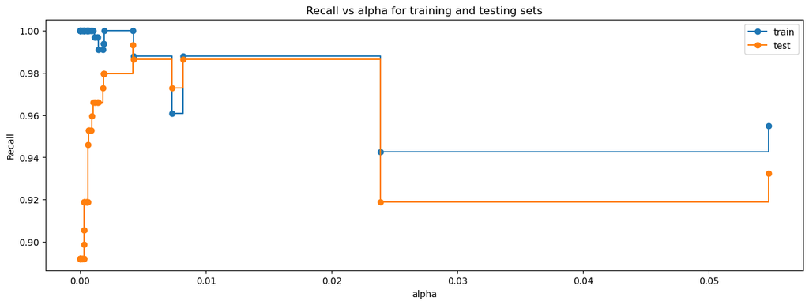

```python
fig, ax = plt.subplots(figsize=(15, 5))
ax.set_xlabel("alpha")
ax.set_ylabel("Recall")
ax.set_title("Recall vs alpha for training and testing sets")
ax.plot(
    ccp_alphas, recall_train, marker="o", label="train", drawstyle="steps-post",
)
ax.plot(ccp_alphas, recall_test, marker="o", label="test", drawstyle="steps-post")
ax.legend()
plt.show()
```

```python
# creating the model where we get highest train and test recall
index_best_model = np.argmax(recall_test)
best_model = clfs[index_best_model]
print(best_model)
```

```
DecisionTreeClassifier(ccp_alpha=0.004211086406830959, class_weight='balanced',
                       random_state=1)
```

- **Checking model performance on training set**

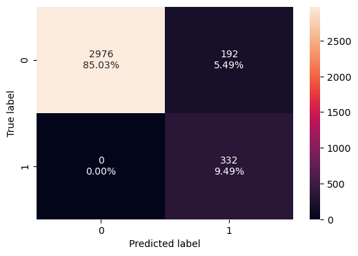

```python
confusion_matrix_sklearn(best_model, X_train, y_train)
```

```python
decision_tree_post_perf_train = model_performance_classification_sklearn(
    best_model, X_train, y_train
)
decision_tree_post_perf_train
```

|  | Accuracy | Recall | Precision | F1 |
| --- | --- | --- | --- | --- |
| 0 | 0.945143 | 1.0 | 0.633588 | 0.775701 |

- **Checking model Perfomance on Test Set**

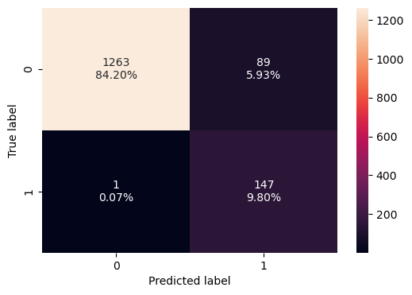

```python
confusion_matrix_sklearn(best_model, X_test, y_test)
```

```python
decision_tree_post_test = model_performance_classification_sklearn(
    best_model, X_test, y_test
)
decision_tree_post_test
```

|  | Accuracy | Recall | Precision | F1 |
| --- | --- | --- | --- | --- |
| 0 | 0.94 | 0.993243 | 0.622881 | 0.765625 |

- In the post-pruned tree also, the model is giving a generalized result since the recall scores on both the train and test data are coming to be around 1 which shows that the model is able to generalize well on unseen data.

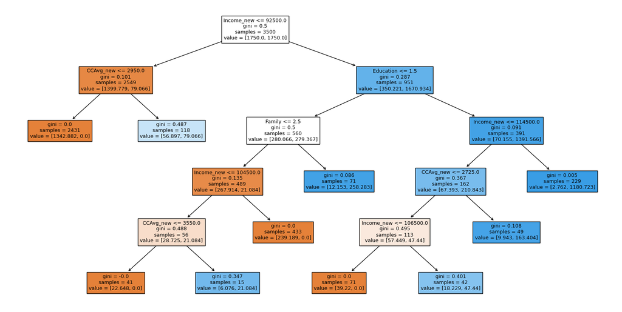

```python
plt.figure(figsize=(20, 10))

out = tree.plot_tree(
    best_model,
    feature_names=feature_names,
    filled=True,
    fontsize=9,
    node_ids=False,
    class_names=None,
)
for o in out:
    arrow = o.arrow_patch
    if arrow is not None:
        arrow.set_edgecolor("black")
        arrow.set_linewidth(1)
plt.show()
```

### Model Perfomance Comparison - Decision Tree

```python
# training performance comparison

models_train_comp_df = pd.concat(
    [
        decision_tree_perf_train_without.T,
        decision_tree_perf_train.T,
        decision_tree_tune_perf_train.T,
        decision_tree_post_perf_train.T,
    ],
    axis=1,
)
models_train_comp_df.columns = [
    "Decision Tree without class_weight",
    "Decision Tree with class_weight",
    "Decision Tree (Pre-Pruning)",
    "Decision Tree (Post-Pruning)",
]
print("Training performance comparison:")
models_train_comp_df
```

```
Training performance comparison:
```

|  | Decision Tree without class_weight | Decision Tree with class_weight | Decision Tree (Pre-Pruning) | Decision Tree (Post-Pruning) |
| --- | --- | --- | --- | --- |
| Accuracy | 1.0 | 1.0 | 0.968571 | 0.945143 |
| Recall | 1.0 | 1.0 | 0.981928 | 1.000000 |
| Precision | 1.0 | 1.0 | 0.758140 | 0.633588 |
| F1 | 1.0 | 1.0 | 0.855643 | 0.775701 |

```python
# testing performance comparison

models_test_comp_df = pd.concat(
    [
        decision_tree_perf_test_without.T,
        decision_tree_perf_test.T,
        decision_tree_tune_perf_test.T,
        decision_tree_post_test.T,
    ],
    axis=1,
)
models_test_comp_df.columns = [
    "Decision Tree without class_weight",
    "Decision Tree with class_weight",
    "Decision Tree (Pre-Pruning)",
    "Decision Tree (Post-Pruning)",
]
print("Test set performance comparison:")
models_test_comp_df
```

```
Test set performance comparison:
```

|  | Decision Tree without class_weight | Decision Tree with class_weight | Decision Tree (Pre-Pruning) | Decision Tree (Post-Pruning) |
| --- | --- | --- | --- | --- |
| Accuracy | 0.984667 | 0.985333 | 0.968000 | 0.940000 |
| Recall | 0.932432 | 0.891892 | 0.972973 | 0.993243 |
| Precision | 0.913907 | 0.956522 | 0.765957 | 0.622881 |
| F1 | 0.923077 | 0.923077 | 0.857143 | 0.765625 |

### Conclusions - Decision Tree

- Decision tree models with pre-pruning and post-pruning both are giving equally high recall scores on both training and test sets.
- However, we will choose the pre pruned tree as the best model since it is giving a slightly high precision score on the train and test sets than the post pruned tree.

## GENERAL CONCLUSION

- From the Two Models which is the decision tree and Logistic regression, The decision tree is performing better than that of the Logistic Regression.
- With Decision Tree, we were able to get a high Recall of 97,Precision of 76 and F1-Score of 85 which is far better than that of logsitic regression which was giving us 64,71 and 67 respespectively for Recall, precision and F1-score when we selected the best model from each of the two Machine learning algorithms.
- We would have to go with the Pre Pruned Model and use that as our Model to help Predict if a customer is eligible for a loan or not.